# Missing Immigrants

Team Migraine

21/06/2021

### Team Members

- Hazal Ünal
- Zeynep Berna İnce

### Project Description

- Project goal & social problem addressed:

Because human beings are not in a position to choose where they want to live in their lives, some may have experienced migration because of inadequate living conditions. A wide range of thoughts can lead to that decision, but in this project, we analyze the migration of the people who are suffering from war and violence. It is difficult to migrate where they want people who were born in unfortunate areas. They must struggle for minimum conditions of livelihood. As part of this project, we will analyze the migration process of those suffering from a lack of security. The data shows people who are lost, sick, and even died in this process and the primary goal of this project is to show missing immigrants’ gender, region, cause of deaths, life expectancy by years with data visualization.

- Project data & access to data:

This project points out the immigrant problem in the world. They struggle many issues since the begining of their life until they found a better place to live in safety and peace. Our goal is to reveal this global situtation. Our dataset has downloaded from [International Organization for Migration (IOM)’s Missing Immigrants Project’s website as excel sheets.](https://missingmigrants.iom.int/downloads)

### Actions Taken

Firstly, we loaded the 2019, 2020 and 2021 data tables from https://missingmigrants.iom.int, where we used the data, to review them. In this project, we have cleaned up the columns that will not be required. We extended our project with our primary goal, the columns of gender, migration route, regions of immigrants, deaths and survivors. There were blank rows in some of these columns, then we filled these rows with mean values so that our analyzes would yield better results. We combined all three years of research to create a single data table. Completely, we rounded the product fractions to see sharper quantities on the graphics. Since we are examining only one parameter in each graph, we have observed the total number of dead and missing immigrants and total number of survivors year by year using a heat map to easily see the difference between the months. We used stacked area graph for visualizing the number of dead and missing immigrants of all regions by years. Before visualizing, we created a new data frame with year data, region data and the number of dead and missing immigrants data. To reach the total missing data, we subtract the total death column from the total missing and dead immigrant column, which will give us this result. So as to we analyze the data we obtained by years and regions, we used the stacked bar chart, which we thought would give the most optimum results. We created a new data frame with total dead and missing data, total survivors data, reported year data and region data. Then created a new feature: life expectancy. And visualized life expectancy of all regions by years with line plot. We started to visualize from gender/headcount graph, then continued to see the ratio of survived and dead immigrants.We tidied causes of deaths and made a list of death causes the visualized it as a tree map to get insight about the most popular death causes. We developed an interactive chart applying all our data via R shiny. In this graph, we can see the value of each column we looked at year by year and region by region, comparatively. Finally, to show the most common migration routes we created a data frame with region data, migration route data, the number of dead and missing data and the number of survivors data. To finding out how frequent the route is, we calculated sum of every dead, missing and survivor immigrants over the years. By using this frequency, we created an interactive word cloud.

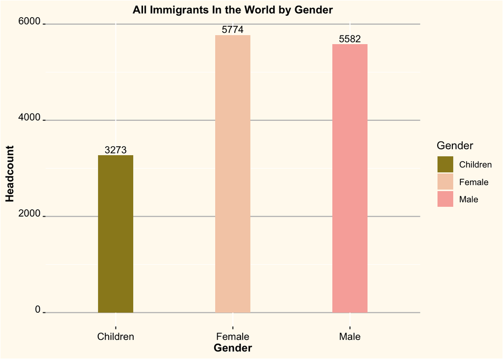

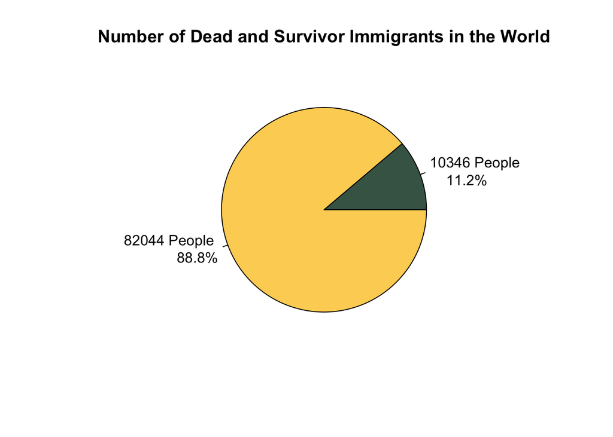

This is a pie chart that shows the total number of survivors and the total number of deaths and missing migrants over the three years we examined at our project. The data we analyzed shows that although 90% of immigrants survived, 10% of the unfortunate immigrants were recorded as dead or missing.

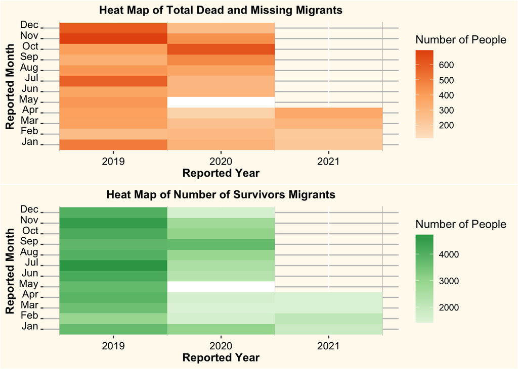

As we observed in the previous pie chart, there is a quiet difference between total dead and survivors. In this graph, we chose to use a heat map in order to determine these data monthly and yearly in the best way.

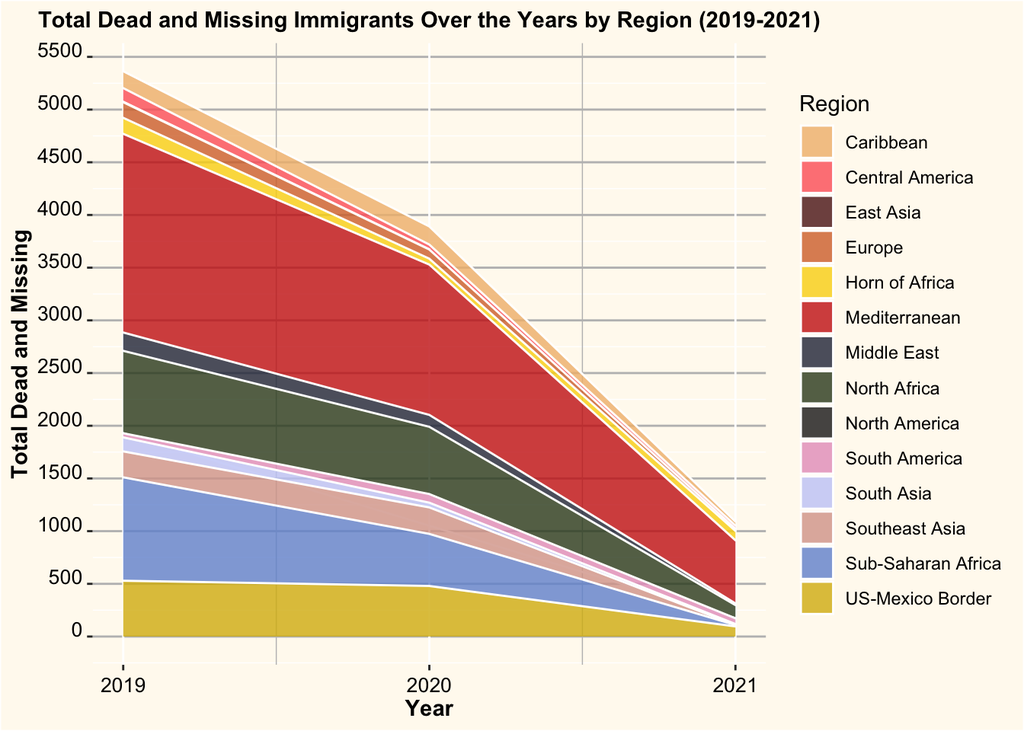

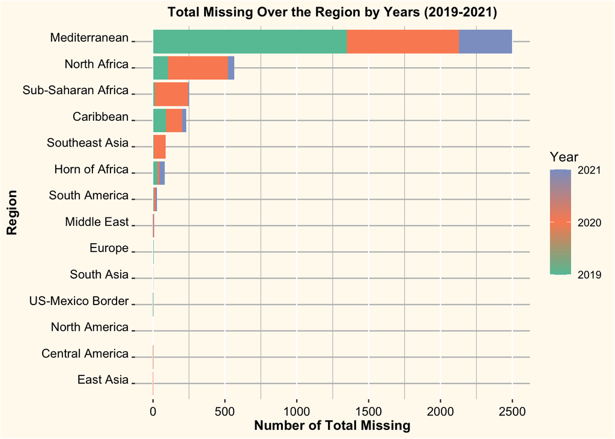

We already analyzed the total death and missing data jointly. In order to know the density of missing migrants in our project, we found the difference in the data on the total number of deaths we have. So we did get missing data on immigrants. We got that information on a regional basis and on a year-by-year basis. What is clear from this chart is that there are far too many missing migrants in the Mediterranean.

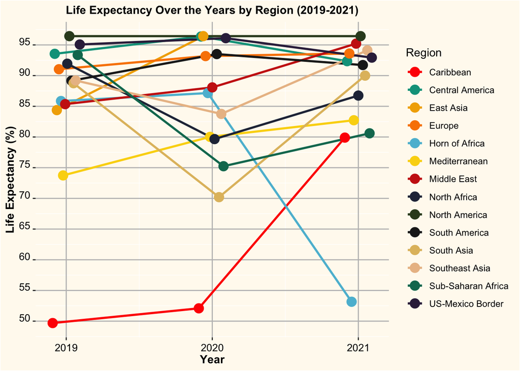

Line graph shows us life expectancy of immigrants is at least 50 %. In South Asia there is a huge decrease between 2019-2020 and a huge increase between 2020-2021. In general, life expectancy rate of the immigrants is higher than 80. And this outcome makes us think that the biggest problem here is missing immigrants.

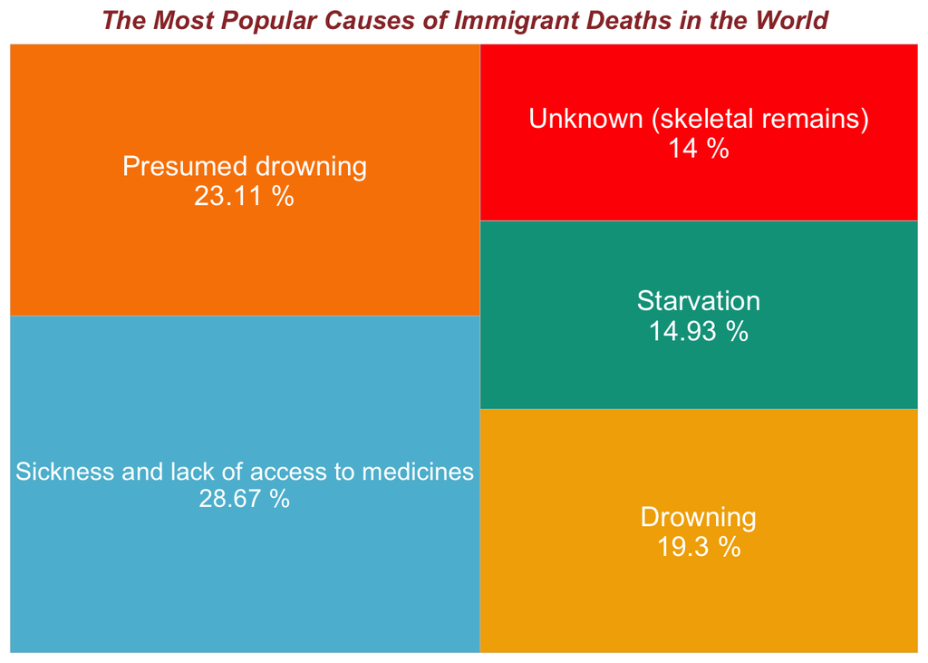

This treemap chart shows us the top five causes of death of immigrants from our data. When we examine presumed drowning and drowning together, it constitutes almost half of this data. This shows us that as immigrants mostly use the sea route as a migration route, deaths on the road record for 50% of their deaths. If we examine the starvation and sickness data together, we can easily say that the poor living conditions of immigrants play a significant role in the death of immigrants.

[interactive chart not shown]

Here’s an interactive word cloud for the migration routes. Eastern Mediterranean and Western Balkans routes have almost same frequency. Especially Eastern Mediterranean supports the number of dead and missing immigrants data we showed above. It’s the second frequent route for migration. Thus, it has the most dead and missing immigrants. By combining these results, we may say that Mediterranean is not a safe place for immigrants. Mediterranean people’s stance on immigrants seems not too good.

### Conclusion

In this R project, a study on data analyzing of missing immigrants is presented. We used [IOM](https://missingmigrants.iom.int/downloads)’s data from 2019, 2020 and 2021. As a result of our data analysis, we observed that 90% of immigrants survived and 10% of unfortunate immigrants are dead and missing depends on several causes. If we reduce the most five common reasons to two, these are poor living conditions and drowning. Due to poor living conditions, immigrants are struggling with starving and sickness. These reasons result in death because they don’t have access to medicines. The second most common reason of immigrant death is drowning as a consequence of using the Mediterranean Sea the most as a migration route. However, life expectancy rate gives similar results in other regions, generally the rate is quite high and over 70%, while in the Caribbean and Horn of Africa it is very low.

### References

-https://missingmigrants.iom.int

-https://shiny.rstudio.com

-https://github.com/karthik/wesanderson

-https://www.r-graph-gallery.com/ggplot2-package.html

-https://www.displayr.com/how-to-make-an-area-chart-in-r/